# Project1

J. Sieber

Thursday, June 19, 2014

## Objective

Create a model to predict activities of people using fitness tracker raw information.

## Model Fit

Load libraries:

```r
library(caret)
library(randomForest)
```

Read in data from working directory. Create a test set, a final train set, cross validation test set, cross validation train set. I used a 70/30 split on the training set to generate the cross validation sets.

```r
test<-read.csv("pml-testing.csv")
train<-read.csv("pml-training.csv")
set.seed(1)
cv<-sample(train$X,size=13735,replace=FALSE)
cvtrain<-train[cv,]
cvtest<-train[-cv,]
```

Set seed so data is reproducable. Set the seed everywhere a random operation occurs.

```r
set.seed(1)
```

Fit a model using the raw training data. I used a random forest to make my model. I tried using train(,model=“rf”) but it was very slow. randomForest() was very quick.

```r
fit<-randomForest(classe~user_name+roll_belt+pitch_belt+
               yaw_belt+gyros_belt_x+gyros_belt_y+gyros_belt_z+accel_belt_x+
               accel_belt_y+accel_belt_z+magnet_belt_x+magnet_belt_y+
               magnet_belt_z+roll_arm+pitch_arm+yaw_arm+total_accel_arm+
                   gyros_arm_x+gyros_arm_y+gyros_arm_z+accel_arm_x+accel_arm_y+
                   accel_arm_z+magnet_arm_x+magnet_arm_y+magnet_arm_z,
               importance=TRUE,
           method="rf",data=cvtrain,ntree=50)
```

## Cross Validation

Show features that were important to the model.

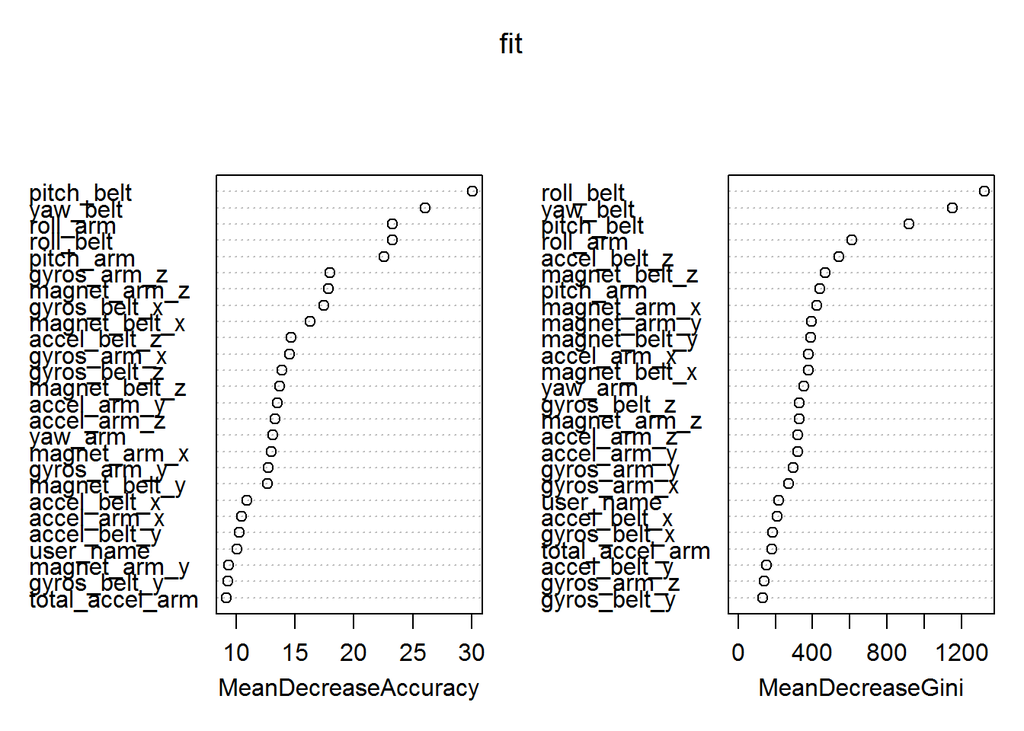

```r
varImpPlot(fit)
```

Make a prediction on the cross validation test set to get an idea how the model did.

```r
pred<-predict(fit,cvtest)
confusionMatrix(pred,cvtest$classe)
```

```
## Confusion Matrix and Statistics
##
##           Reference
## Prediction    A    B    C    D    E
##          A 1640   24    4    3    0
##          B    7 1107   25    1    3
##          C    9    8 1043   19    2
##          D    6    0    9  942    1
##          E    4    1    1    1 1027
##
## Overall Statistics
##
##                Accuracy : 0.978
##                  95% CI : (0.974, 0.982)
##     No Information Rate : 0.283
##     P-Value [Acc > NIR] : < 2e-16
##
##                   Kappa : 0.973
##  Mcnemar's Test P-Value : 0.000608
##
## Statistics by Class:
##
##                      Class: A Class: B Class: C Class: D Class: E
## Sensitivity             0.984    0.971    0.964    0.975    0.994
## Specificity             0.993    0.992    0.992    0.997    0.999
## Pos Pred Value          0.981    0.969    0.965    0.983    0.993
## Neg Pred Value          0.994    0.993    0.992    0.995    0.999
## Prevalence              0.283    0.194    0.184    0.164    0.175
## Detection Rate          0.279    0.188    0.177    0.160    0.174
## Detection Prevalence    0.284    0.194    0.184    0.163    0.176
## Balanced Accuracy       0.989    0.982    0.978    0.986    0.996
```

The model seemed to fit well on the cross validation test set. I then used the full train data to create a new fit. The fit on the model with the full training set will be better then the cross validation training set.

```r
set.seed(1)
fit<-randomForest(classe~user_name+roll_belt+pitch_belt+
               yaw_belt+gyros_belt_x+gyros_belt_y+gyros_belt_z+accel_belt_x+
               accel_belt_y+accel_belt_z+magnet_belt_x+magnet_belt_y+
               magnet_belt_z+roll_arm+pitch_arm+yaw_arm+total_accel_arm+
                   gyros_arm_x+gyros_arm_y+gyros_arm_z+accel_arm_x+accel_arm_y+
                   accel_arm_z+magnet_arm_x+magnet_arm_y+magnet_arm_z,
               importance=TRUE,
           method="rf",data=train,ntree=50)
```

I then used the new fit to make the predictions on the test set.

```r
pred<-predict(fit,test)
pred
```

```
##  1  2  3  4  5  6  7  8  9 10 11 12 13 14 15 16 17 18 19 20
##  B  A  B  A  A  E  D  B  A  A  B  C  B  A  E  E  A  B  B  B
## Levels: A B C D E
```

I used the supplied function to generate the text files needed for submission.

```r
write_files = function(x){
    n = length(x)
    for(i in 1:n){
        filename = paste0("problem_id_",i,".txt")
        write.table(x[i],file=filename,quote=FALSE,row.names=FALSE,col.names=FALSE)
    }
}
```